# Homework 3 PSTAT 131/231

Jai Uparkar

## Classification

For this assignment, we will be working with part of a [Kaggle data set](https://www.kaggle.com/c/titanic/overview) that was the subject of a machine learning competition and is often used for practicing ML models. The goal is classification; specifically, to predict which passengers would survive the [Titanic shipwreck](https://en.wikipedia.org/wiki/Titanic).

Load the data from `data/titanic.csv` into *R* and familiarize yourself with the variables it contains using the codebook (`data/titanic_codebook.txt`).

Notice that `survived` and `pclass` should be changed to factors. When changing `survived` to a factor, you may want to reorder the factor so that *“Yes”* is the first level.

Make sure you load the `tidyverse` and `tidymodels`!

*Remember that you’ll need to set a seed at the beginning of the document to reproduce your results.*

```r
titanic_df<-read.csv('data/titanic.csv')
titanic_df <- titanic_df %>%
  mutate(survived = factor(survived, levels = c("Yes", "No")),
         pclass = factor(pclass))
```

### Question 1

Split the data, stratifying on the outcome variable, `survived.` You should choose the proportions to split the data into. Verify that the training and testing data sets have the appropriate number of observations. Take a look at the training data and note any potential issues, such as missing data.

Why is it a good idea to use stratified sampling for this data?

```r
titanic_split <- initial_split(titanic_df, prop = 0.7,
                                strata = survived)
titanic_train <- training(titanic_split)
titanic_test <- testing(titanic_split)

titanic_train %>%
  summary()
summary(titanic_df$survived)
```

[output not shown]

It would be a good idea to use stratified sampling for this idea because of the outcomes for survival are skewed. In our case around 62% of the passengers did not survive and the other 38% did meaning that the levels are not balanced. Some key notes is that the training data set only gets is missingness from the age variable in the testing data set with approximately 241 missing values.

### Question 2

Using the **training** data set, explore/describe the distribution of the outcome variable `survived`.

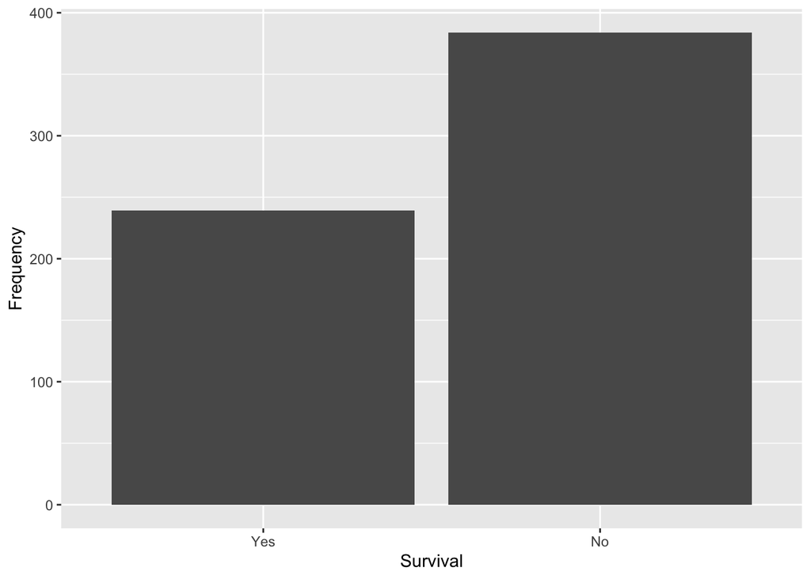

```r
titanic_train %>%
  ggplot(aes(x = survived)) +
  geom_bar() +
  xlab("Survival") +
  ylab("Frequency")
```

I discovered a similar relationship between the number of the survivals in the training data set compared to the overall. In the overall data set, there is still an imbalance of outcomes with 61 % of the outcomes being No and the rest are Yes. This is a slightly better distribution compared to the overall data set as I described previously.

### Question 3

Using the **training** data set, create a correlation matrix of all continuous variables. Create a visualization of the matrix, and describe any patterns you see. Are any predictors correlated with each other? Which ones, and in which direction?

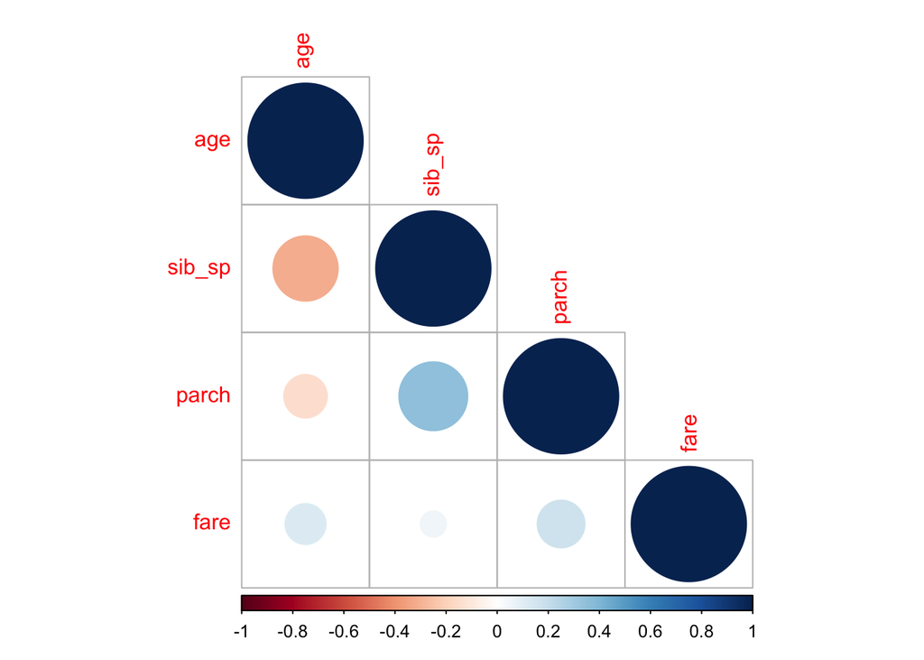

```r
titanic_train %>%
  dplyr::select(is.numeric, -c(passenger_id)) %>%
  cor(use = "complete.obs") %>%
  corrplot(type = "lower")
```

A significant relationship I see is that sip_sp & age and parch & age are negatively correlated. This means that older passengers are less likely to have siblings on board with them. There is a positive relationship between parch and sip_pb meaning that having one sibling on board likely means the other is on board too.

### Question 4

Using the **training** data, create a recipe predicting the outcome variable `survived`. Include the following predictors: ticket class, sex, age, number of siblings or spouses aboard, number of parents or children aboard, and passenger fare.

Recall that there were missing values for `age`. To deal with this, add an imputation step using `step_impute_linear()`. Next, use `step_dummy()` to **dummy** encode categorical predictors. Finally, include interactions between:

- Sex and passenger fare, and
- Age and passenger fare.

You’ll need to investigate the `tidymodels` documentation to find the appropriate step functions to use.

```r
titanic_recipe <- recipe(survived~pclass + sex + age +
                           sib_sp + parch + fare, titanic_train)  %>%
  step_impute_linear(age, impute_with = imp_vars(sib_sp)) %>%
  step_dummy(all_nominal_predictors()) %>%
  step_interact(terms = ~ starts_with("sex"):age + fare:age)
```

### Question 5

Specify a **logistic regression** model for classification using the `"glm"` engine. Then create a workflow. Add your model and the appropriate recipe. Finally, use `fit()` to apply your workflow to the **training** data.

*Hint: Make sure to store the results of `fit()`. You’ll need them later on.*

```r
log_model <- logistic_reg() %>%
  set_engine("glm") %>%
  set_mode("classification")

titanic_workflow_log <- workflow() %>%
  add_model(log_model)  %>%
  add_recipe(titanic_recipe)

titanic_fit_log <- fit(titanic_workflow_log, titanic_train)
```

### Question 6

**Repeat Question 5**, but this time specify a linear discriminant analysis model for classification using the `"MASS"` engine.

```r
MASS_model <- parsnip::discrim_linear() %>%
  set_engine("MASS") %>%
  set_mode("classification")

titanic_workflow_MASS <- workflow() %>%
  add_model(MASS_model) %>%
  add_recipe(titanic_recipe)

titanic_fit_MASS <- fit(titanic_workflow_MASS, data = titanic_train)
```

### Question 7

**Repeat Question 5**, but this time specify a quadratic discriminant analysis model for classification using the `"MASS"` engine.

```r
MASS2_model <- discrim_quad() %>%
  set_engine("MASS") %>%
  set_mode("classification")

titanic_workflow_MASS2 <- workflow() %>%
  add_model(MASS2_model) %>%
  add_recipe(titanic_recipe)

titanic_fit_MASS2 <- fit(titanic_workflow_MASS2, data = titanic_train)
```

### Question 8

**Repeat Question 5**, but this time specify a naive Bayes model for classification using the `"klaR"` engine. Set the `usekernel` argument to `FALSE`.

```r
klar_model <- naive_Bayes() %>%
  set_engine("klaR") %>%
  set_mode("classification") %>%
  set_args(usekernal = FALSE)

titanic_workflow_klar_model <- workflow() %>%
  add_model(klar_model) %>%
  add_recipe(titanic_recipe)

titanic_fit_klar_model <- fit(titanic_workflow_klar_model, data = titanic_train)
```

### Question 9

Now you’ve fit four different models to your training data.

Use `predict()` and `bind_cols()` to generate predictions using each of these 4 models and your **training** data. Then use the *accuracy* metric to assess the performance of each of the four models.

Which model achieved the highest accuracy on the training data?

```r
log_model_predict <- predict(titanic_fit_log, titanic_train,  type = "class") %>%
  bind_cols(titanic_train %>% dplyr::select(survived))  %>%
  accuracy(truth = survived, estimate = .pred_class)

MASS1_model_predict <- predict(titanic_fit_MASS, titanic_train,  type = "class") %>%
  bind_cols(titanic_train %>% dplyr::select(survived))  %>%
  accuracy(truth = survived, estimate = .pred_class)

MASS2_model_predict <- predict(titanic_fit_MASS2, titanic_train,  type = "class") %>%
  bind_cols(titanic_train %>% dplyr::select(survived))  %>%
  accuracy(truth = survived, estimate = .pred_class)

klar_model_predict <- predict(titanic_fit_klar_model, titanic_train,  type = "class") %>%
  bind_cols(titanic_train %>% dplyr::select(survived))  %>%
  accuracy(truth = survived, estimate = .pred_class)

results_acc <- bind_rows(log_model_predict, MASS1_model_predict, MASS2_model_predict, klar_model_predict) %>%
  tibble() %>% mutate(model = c("Logistic", "Linear DA", "Quadratic DA", "Naive Bayes")) %>%
  dplyr::select(model, .estimate)

tibble(results_acc)
```

```
## # A tibble: 4 × 2
##   model        .estimate
##   <chr>            <dbl>
## 1 Logistic         0.830
## 2 Linear DA        0.815
## 3 Quadratic DA     0.815
## 4 Naive Bayes      0.801
```

From the tibble above we can see that the model that performed the best on the training data was the logistic discriminant analysis since it has the highest estimate value.

### Question 10

Fit the model with the highest training accuracy to the **testing** data. Report the accuracy of the model on the **testing** data.

Again using the **testing** data, create a confusion matrix and visualize it. Plot an ROC curve and calculate the area under it (AUC).

How did the model perform? Compare its training and testing accuracies. If the values differ, why do you think this is so?

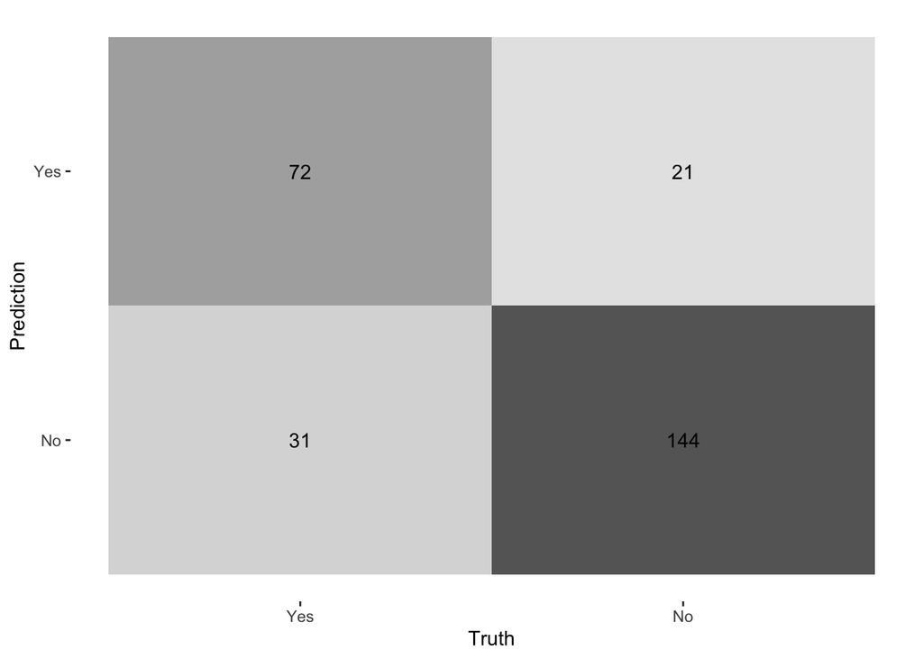

```r
log_test <- fit(titanic_workflow_log, titanic_test)

test_acc<- predict(log_test, new_data = titanic_test, type = "class") %>%
  bind_cols(titanic_test %>% dplyr::select(survived)) %>%
  accuracy(truth = survived, estimate = .pred_class)

test_acc

conf_m<- augment(log_test, new_data = titanic_test) %>%
  conf_mat(truth = survived, estimate = .pred_class) %>%
  autoplot(type = "heatmap")

conf_m
```

[output not shown]

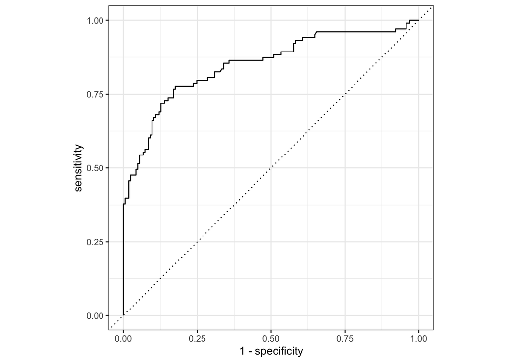

```r
ROC_plot<- augment(log_test, new_data = titanic_test) %>%
  roc_curve(survived, .pred_Yes) %>%
  autoplot()

ROC_plot
```

### 231:Question 11

In a binary classification problem, let $p$ represent the probability of class label $1$, which implies that $1 - p$ represents the probability of class label $0$. The *logistic function* (also called the “inverse logit”) is the cumulative distribution function of the logistic distribution, which maps a real number *z* to the open interval $(0, 1)$.

Given that:

$$P(z)=\frac{e^z}{1+e^z}$$

Prove that the inverse of a logistic function is indeed the *logit* function: Let P(z) = t, such that
$$P(z)=\frac{e^z}{1+e^z} = t$$
$$t + te^z = e^z$$

$$t = te^z - e^z$$
$$t = e^z(1-t)$$
$$e^z =\frac{t}{1-t}$$
$$ln(e^z) =ln(\frac{t}{1-t})$$
$$z =ln(\frac{t}{1-t})$$
Substituting z(p) back in for t we have,
$$z(p) =ln(\frac{p}{1-p})$$

### 231:Question 12

Assume that $z = \beta_0 + \beta_{1}x_{1}$ and $p = logistic(z)$. How do the odds of the outcome change if you increase $x_{1}$ by two? Demonstrate this.

Assume now that $\beta_1$ is negative. What value does $p$ approach as $x_{1}$ approaches $\infty$? What value does $p$ approach as $x_{1}$ approaches $-\infty$?

2 units that means you increase X by 1-unit twice and increase X by unit twice means you multiply the odds by $e^{2\beta_1}$

When $\beta_1$ is negative and as x approaches $\infty$ , p approaches 0. This is because $\frac{p}{1-p}$ is approaching 0.

When $\beta_1$ is negative and as x approaches $-\infty$, p approaches 1.This is because $\frac{p}{1-p}$ is approaching 1.